# 105.4. Synthetic source injection

For the Rubin Science Platform at data.lsst.cloud.  
Data Release: [Data Preview 2](https://dp2.lsst.io/)  
Container Size: large  
LSST Science Pipelines version: r30.0.11  
Last verified to run: 2026-11-16  
Repository: github.com/lsst/tutorial-notebooks  
DOI: 10.11578/rubin/dc.20250909.20

**Learning objective:** Use LSST Science Pipelines tools to inject synthetic sources into a deep coadd image.

**LSST data products:** `deep_coadd`

**Packages:** `lsst.source.injection`, `lsst.images`, `lsst.daf.butler`, `lsst.geom`

**Credit:** Originally developed by Jeff Carlin in collaboration with Lee Kelvin and the Rubin Community Science Team. Much of the material is based on the documentation for the LSST [source_injection package](https://pipelines.lsst.io/v/daily/modules/lsst.source.injection/index.html). Please consider acknowledging them if this notebook is used for the preparation of journal articles, software releases, or other notebooks.

**Get Support:** Everyone is encouraged to ask questions or raise issues in the [Support Category](https://rubin.community/c/support) of the Rubin Community Forum. Rubin staff will respond to all questions posted there.

> **Warning:** This tutorial works with a `deep_coadd` as an `lsst.images` `CellCoadd` object (https://images.lsst.io/). However, the source injection task in the current recommended version of the LSST Science Pipelines requires an `ExposureF` object, which is being deprecated in favor of `lsst.images` objects. The `deep_coadd` is therefore converted to an `ExposureF` only for the injection step itself (Section 4.1). Future versions of the LSST Science Pipelines are expected to support injection directly into a `CellCoadd`.

## 1. Introduction

This notebook demonstrates the use of the `source_injection` package from the LSST Science Pipelines to inject artificial sources (stars and galaxies) into images using the images' measured point-spread function, WCS, and photometric calibration. Sources can be injected into images produced during various stages of Pipelines processing, including visit-level images (e.g., `visit_image`s), any dataset with a `datasetType` of `Exposure` (e.g., `post_isr_image`), and coadd images (e.g., `deep_coadd`s). This notebook demonstrates injection into a `deep_coadd`. The driver that both creates and injects synthetic sources into images is based on [Galsim](https://galsim-developers.github.io/GalSim/), enabling injection of many types of sources, including stars, a variety of parameterized galaxy models, and postage stamp images.

Injecting directly into a `deep_coadd` is fast and convenient, and the injected sources are rendered with the coadd's own PSF. The most realistic approach, however, is to inject sources into the individual exposures and then build coadds from them, so that the injected sources go through the same processing as the real ones.

This notebook teaches some basics of using the `source_injection` package to insert artificial sources into images. Read the extensive [documentation](https://pipelines.lsst.io/v/daily/modules/lsst.source.injection/index.html) for more details and examples. Furthermore, the [Galsim](https://galsim-developers.github.io/GalSim/) documentation provides much more detail on the types of sources that can be injected.

**Related tutorials:** The 105-series notebook tutorials about detecting and measuring sources and forced photometry.

### 1.1. Import packages

Import `numpy`, a fundamental package for scientific computing with arrays in Python (numpy.org), and `matplotlib`, a comprehensive library for data visualization ([matplotlib.org](https://matplotlib.org/); [matplotlib gallery](https://matplotlib.org/stable/gallery/index.html)). Tools from [Astropy](https://www.astropy.org/) will be used to read a FITS image, and work with Tables, sky coordinates, and units.

From the `lsst` package, import the butler, the `Image` class from `lsst.images` ([images.lsst.io](https://images.lsst.io/)), `lsst.geom` for the sky position used to look up the skymap, the `lsst.source.injection` package to inject synthetic sources into images, and image display functions from the LSST Science Pipelines ([pipelines.lsst.io](https://pipelines.lsst.io/)).

```python
import numpy as np
import matplotlib.pyplot as plt
from lsst.daf.butler import Butler
from lsst.images import Image
import lsst.afw.display as afwDisplay
import lsst.geom as geom

from astropy.io import fits
from astropy.table import Table, vstack
from astropy.coordinates import SkyCoord, Angle
import astropy.units as u

from lsst.source.injection import generate_injection_catalog
from lsst.source.injection import CoaddInjectConfig, CoaddInjectTask
```

### 1.2. Define parameters and functions

Set `afwDisplay` to use matplotlib.

```python
afwDisplay.setDefaultBackend("matplotlib")
```

Create an instance of the butler pointing to the DP2 repository and collection, and assert it exists.

```python
butler = Butler("dp2", collections="dp2")
assert butler is not None
```

## 2. Retrieve an image

### 2.1. Select a `deep_coadd`

Identify the deep coadd that contains a particular sky position, to inject sources into.

Coadds are divided into `tract`s and `patch`es of a `skymap`. Neighboring patches overlap slightly at their edges, so a butler query for patches that overlap a position can return a patch for which that position lies near the edge. Instead, retrieve the skymap from the butler and use it to find the tract and patch whose inner region (i.e., excluding the overlaps) contains the position.

Define the position, near the center of the ECDFS field, and the band.

```python
ra = 53.076
dec = -28.110
band = 'r'
```

Find the tract and patch that contain the position.

```python
skymap_name = 'lsst_cells_v2'
skymap = butler.get('skyMap', skymap=skymap_name)

coord = geom.SpherePoint(ra, dec, geom.degrees)
tract_info = skymap.findTract(coord)
patch_info = tract_info.findPatch(coord)
tract = tract_info.getId()
patch = tract_info.getSequentialPatchIndex(patch_info)
print('tract: ', tract, ' patch: ', patch)
```

```
tract:  5063  patch:  15
```

Retrieve the $r$-band `deep_coadd` for this tract and patch. By default, the butler returns a `deep_coadd` as an `lsst.images` `CellCoadd` object. Print its type and its pixel units.

```python
deep_coadd = butler.get('deep_coadd', skymap=skymap_name, tract=tract, patch=patch, band=band)
print(type(deep_coadd))
print('Pixel units: ', deep_coadd.unit)
```

```
<class 'lsst.images.cells._coadd.CellCoadd'>
Pixel units:  nJy
```

#### 2.1.1. Extract the image center and dimensions

To generate synthetic sources to inject into the image, the coordinates and size of its bounding box are necessary.

Use the image's bounding box (`bbox`) and its sky projection (`sky_projection`, which maps pixel coordinates to sky coordinates and back) to extract the central (RA, Dec) coordinate, as an Astropy `SkyCoord`, and the image size in degrees. The size is computed as the angular separation between pixels on opposite edges of the image.

Also print the bounding box and the type of PSF. The bounding box does not start at pixel (0, 0): the pixel coordinates of a coadd are those of the whole tract, and the patch is positioned within it. DP2 coadds are cell-based: each patch is divided into small cells, each with its own PSF model, and these are combined into a `CellPointSpreadFunction`.

```python
bbox = deep_coadd.bbox
proj = deep_coadd.sky_projection

cen = proj.pixel_to_sky(x=bbox.x.center, y=bbox.y.center)

left = proj.pixel_to_sky(x=bbox.x.min, y=bbox.y.center)
right = proj.pixel_to_sky(x=bbox.x.max, y=bbox.y.center)
bottom = proj.pixel_to_sky(x=bbox.x.center, y=bbox.y.min)
top = proj.pixel_to_sky(x=bbox.x.center, y=bbox.y.max)

width = float(left.separation(right).deg)
height = float(bottom.separation(top).deg)

imsize = (width, height)

print('Image center in (RA, Dec): ', cen.ra.deg, cen.dec.deg)
print('Size of deep_coadd in degrees: ', imsize)
print('Bounding box: ', bbox)
print('PSF type: ', type(deep_coadd.psf).__name__)
```

```
Image center in (RA, Dec):  52.9930589718291 -28.103914179832266
Size of deep_coadd in degrees:  (0.1832677364776037, 0.18325843387875684)
Bounding box:  [y=2850:6150, x=14850:18150]
PSF type:  CellPointSpreadFunction
```

## 3. Make a catalog of synthetic sources

Having retrieved a `deep_coadd` to inject into, now set up a simple synthetic source catalog.

### 3.1. Make a catalog of galaxies and stars

The `source_injection` package provides tools to create catalogs of synthetic sources. Here, use the `generate_injection_catalog` function to create the sources to inject.

Injection catalogs are defined in sky coordinates (RA, Dec), so a catalog can be injected into any image that overlaps it. Here, define the catalog to cover the coadd patch.

Set `inject_size`, the half-width of the region in which sources are placed, to 90% of half the patch width as determined above, so that sources are not placed right at the patch edges. Lines of constant RA converge toward the poles, so a given angular distance on the sky corresponds to a larger range in RA by a factor of $1/\cos({\rm Dec})$; apply this factor to the RA limits so that the sources span the full width of the patch.

```python
inject_size = 0.9 * imsize[0] / 2
ra_c = cen.ra.deg
dec_c = cen.dec.deg
ra_half = inject_size / np.cos(np.radians(dec_c))

ra_lim = [float(ra_c - ra_half), float(ra_c + ra_half)]
dec_lim = [float(dec_c - inject_size), float(dec_c + inject_size)]
print('RA limits: ', ra_lim)
print('Dec limits: ', dec_lim)
```

```
RA limits:  [52.89956506163442, 53.08655288202378]
Dec limits:  [-28.18638466124719, -28.021443698417343]
```

#### 3.1.1. Galaxies

The simplest form of a galaxy in Galsim is parameterized by a [Sersic model](https://en.wikipedia.org/wiki/S%C3%A9rsic_profile): $I(r) = I_e~{\rm exp}\{-b_n [(\frac{r}{r_e})^{1/n}-1]\}$, which defines the shape of the galaxy's light profile as a function of radius (r) in terms of the "Sersic index" (n) and the "half-light radius" ($r_e$). (Note that $n = 1$ corresponds to an exponential profile.)

The above equation results in a circular galaxy. To create elongated (elliptical) Sersic profiles, additionally specify the minor-to-major axis ratio (q) with a rotation angle (beta).

`generate_injection_catalog` will automatically generate sources with all possible permutations of the parameters you provide. For example, the cell below specifies "number=2" to create 2 synthetic galaxies, but then specifies a single magnitude (mag), 3 values of Sersic index (n), 3 values of axis ratio (q), 2 values of beta, and a single value for half_light_radius. This should result in $2*1*3*3*2*1 = 36$ different combinations of those parameters.

Finally, provide the minimum and maximum RA and Dec coordinates in degrees defined above. In this case, `generate_injection_catalog` will randomly select positions within those limits.

```python
my_injection_catalog_galaxies = generate_injection_catalog(
    ra_lim=ra_lim,
    dec_lim=dec_lim,
    number=2,
    seed='3210',
    source_type="Sersic",
    mag=[15.0],
    n=[1, 2, 4],
    q=[0.9, 0.5, 0.1],
    beta=[31.0, 144.0],
    half_light_radius=[5.0],
)
```

```
lsst.source.injection.utils._generate_injection_catalog INFO: Generated an injection catalog containing 36 sources: 18 combinations repeated 2 times.
```

#### 3.1.2. Stars

Using a similar method, create a catalog of stars to be injected. Specify 7 values of magnitude, with 7 instances, which will result in 49 stars.

```python
my_injection_catalog_stars = generate_injection_catalog(
    ra_lim=ra_lim,
    dec_lim=dec_lim,
    number=7,
    seed='432',
    mag=[19.0, 19.5, 20.0, 20.5, 21.0, 21.5, 22.0],
    source_type="Star",
)
```

```
lsst.source.injection.utils._generate_injection_catalog INFO: Generated an injection catalog containing 49 sources: 7 combinations repeated 7 times.
```

#### 3.1.3. Combine catalogs

Before combining the catalogs, offset the `injection_id` values for the star catalog by 1000 to avoid overlapping with the galaxy ids.

Use the [vstack](https://docs.astropy.org/en/stable/table/operations.html#id4) method from Astropy's [Table](https://docs.astropy.org/en/stable/table/index.html) class to combine the galaxy and star catalogs.

```python
my_injection_catalog_stars['injection_id'] += 1000

inject_cat = vstack([my_injection_catalog_galaxies, my_injection_catalog_stars])
```

Inspect the catalog.

```python
inject_cat
```

*Table length=85*

| injection_id int64 | ra float64 | dec float64 | source_type str6 | mag float64 | n int64 | q float64 | beta float64 | half_light_radius float64 |
| --- | --- | --- | --- | --- | --- | --- | --- | --- |
| 0 | 53.07747750078901 | -28.13143118232056 | Sersic | 15.0 | 1 | 0.9 | 31.0 | 5.0 |
| 1 | 52.966453482432826 | -28.029615773166338 | Sersic | 15.0 | 1 | 0.9 | 31.0 | 5.0 |
| 10 | 52.90801978856115 | -28.052015163180265 | Sersic | 15.0 | 1 | 0.9 | 144.0 | 5.0 |
| 11 | 52.90217641917398 | -28.174193654165336 | Sersic | 15.0 | 1 | 0.9 | 144.0 | 5.0 |
| 20 | 53.03657391507883 | -28.1395764150529 | Sersic | 15.0 | 1 | 0.5 | 31.0 | 5.0 |
| 21 | 52.98398359059433 | -28.119213333222056 | Sersic | 15.0 | 1 | 0.5 | 31.0 | 5.0 |
| 30 | 52.948923374271324 | -28.045906238631012 | Sersic | 15.0 | 1 | 0.5 | 144.0 | 5.0 |
| 31 | 53.013200437530166 | -28.0479425468141 | Sersic | 15.0 | 1 | 0.5 | 144.0 | 5.0 |
| 40 | 52.91386315794832 | -28.09477763502504 | Sersic | 15.0 | 1 | 0.1 | 31.0 | 5.0 |
| 41 | 53.05410402324034 | -28.03979731408176 | Sersic | 15.0 | 1 | 0.1 | 31.0 | 5.0 |
| 50 | 53.0248871763045 | -28.033688389532507 | Sersic | 15.0 | 1 | 0.1 | 144.0 | 5.0 |
| 51 | 53.007357068143 | -28.168084729616083 | Sersic | 15.0 | 1 | 0.1 | 144.0 | 5.0 |
| 60 | 53.068712446708254 | -28.176229962348422 | Sersic | 15.0 | 2 | 0.9 | 31.0 | 5.0 |
| 61 | 52.919706527335485 | -28.15790318870066 | Sersic | 15.0 | 2 | 0.9 | 31.0 | 5.0 |
| 70 | 53.04826065385317 | -28.16197580506683 | Sersic | 15.0 | 2 | 0.9 | 144.0 | 5.0 |
| 71 | 52.93139326610982 | -28.14364903141907 | Sersic | 15.0 | 2 | 0.9 | 144.0 | 5.0 |
| ... | ... | ... | ... | ... | ... | ... | ... | ... |
| 1044 | 52.989979113507545 | -28.084238047246544 | Star | 21.0 | -- | -- | -- | -- |
| 1045 | 52.960762266571706 | -28.133109443640574 | Star | 21.0 | -- | -- | -- | -- |
| 1046 | 52.914015311474365 | -28.04147557540177 | Star | 21.0 | -- | -- | -- | -- |
| 1050 | 53.004587536975464 | -28.135145751823657 | Star | 21.5 | -- | -- | -- | -- |
| 1051 | 52.90232857270003 | -28.10460112907739 | Star | 21.5 | -- | -- | -- | -- |
| 1052 | 53.01919596044338 | -28.08627435542963 | Star | 21.5 | -- | -- | -- | -- |
| 1053 | 52.94907552779737 | -28.031294034486347 | Star | 21.5 | -- | -- | -- | -- |
| 1054 | 52.96660563595887 | -28.047584499951025 | Star | 21.5 | -- | -- | -- | -- |
| 1055 | 53.063021230847134 | -28.0374029590356 | Star | 21.5 | -- | -- | -- | -- |
| 1056 | 53.016274275749794 | -28.110710053626644 | Star | 21.5 | -- | -- | -- | -- |
| 1060 | 53.07470796962147 | -28.165690374569927 | Star | 22.0 | -- | -- | -- | -- |
| 1061 | 53.04256943799205 | -28.14125467637291 | Star | 22.0 | -- | -- | -- | -- |
| 1062 | 52.96952732065245 | -28.092383279978883 | Star | 22.0 | -- | -- | -- | -- |
| 1063 | 53.00166585228188 | -28.127000519091318 | Star | 22.0 | -- | -- | -- | -- |
| 1064 | 53.02796101452413 | -28.07405650633112 | Star | 22.0 | -- | -- | -- | -- |
| 1065 | 53.077629654315054 | -28.1819808400346 | Star | 22.0 | -- | -- | -- | -- |
| 1066 | 52.9081719420872 | -28.16365406638684 | Star | 22.0 | -- | -- | -- | -- |

### 3.2. Add a postage stamp image entry

In addition to parameterized sources of many types, a postage-stamp image (for example, an output image from a simulation) can also be injected. This can be any image; the only requirement is that it must be in FITS format and have a valid WCS. This notebook demonstrates injection of an [SDSS g-band image](https://ned.ipac.caltech.edu/byname?objname=NGC+4152&hconst=67.8&omegam=0.308&omegav=0.692&wmap=4&corr_z=1) of the galaxy PGC 038749 downloaded from the NASA/IPAC Extragalactic Database (NED).

Load the image, then display it to see what it depicts:

```python
stamp_path = '/rubin/cst_repos/tutorial-notebooks-data/data/'
stamp_img_hdu = fits.open(stamp_path + 'PGC_038749_I_g_bbl2011.fits')
```

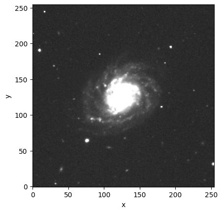

```python
fig = plt.figure()
plt.subplot()
im = plt.imshow(stamp_img_hdu[0].data, cmap='gray', vmin=-20.0, vmax=100, origin='lower')
plt.xlabel('x')
plt.ylabel('y')
plt.show()
```

> **Figure 1**: The SDSS g-band image of PGC 038749 displayed in grayscale, with axes in pixel coordinates.

Add a postage stamp entry into the injection catalog, using `vstack` to add an astropy `Table` containing a single row. Specify its position, magnitude, and `source_type` of `Stamp`, in addition to the filename of the image to inject. (It is fine to leave unnecessary columns empty.)

```python
my_injection_catalog_stamp = Table(
    {
        'injection_id': [9999],
        'ra': [cen.ra.deg + 0.01],
        'dec': [cen.dec.deg - 0.01],
        'source_type': ['Stamp'],
        'mag': [14.8],
        'stamp': [stamp_path + 'PGC_038749_I_g_bbl2011.fits'],
    }
)

inject_cat = vstack([inject_cat, my_injection_catalog_stamp])
```

Option to view the injection catalog:

```python
# inject_cat
```

## 4. Inject sources into an image

In Section 3, a catalog specifying the synthetic sources to inject was created.

Now run the task from `source_injection` that injects sources into the `deep_coadd` that was retrieved earlier, using the point spread function (PSF), photometric calibration, and WCS (World Coordinate System) of the `deep_coadd`.

In the RSP’s current recommended version of the LSST Science Pipelines, the injection task requires its input image to be an `ExposureF`, and its PSF, WCS, and photometric calibration to be the legacy `lsst.afw` objects that an `ExposureF` carries, rather than their `lsst.images` equivalents. Convert the `deep_coadd` to an `ExposureF` just before injection, use it only for the injection, and convert the injected image back to an `lsst.images` `Image` afterward.

### 4.1. Convert the deep coadd to an `ExposureF`

Use the `to_legacy` method of the `CellCoadd` to create an `ExposureF` version of the `deep_coadd`. The `ExposureF` carries the coadd's PSF (as a `StitchedPsf`, the legacy equivalent of the `CellPointSpreadFunction`), WCS, and photometric calibration.

The injection task edits its input image in place. Setting `copy=True` makes the `ExposureF` an independent copy of the pixel data, so that the original `deep_coadd` is not modified by the injection and can be compared with the injected image later in this notebook.

```python
legacy_coadd = deep_coadd.to_legacy(copy=True)
print(type(legacy_coadd))
```

```
<class 'lsst.afw.image._exposure.ExposureF'>
```

### 4.2. Instantiate the injection classes

First, instantiate the `CoaddInjectConfig` class. The `CoaddInjectConfig` class is where configuration of the injection task occurs, allowing for modifications to be made to how the task operates.

Then, after one configuration change (described below), instantiate the `CoaddInjectTask`, using `inject_config` as the configuration argument.

**Note:** More generally, depending on the dataset type being injected into, use the appropriate option from the following list:

```
from lsst.source.injection import CoaddInjectConfig, CoaddInjectTask

from lsst.source.injection import ExposureInjectConfig, ExposureInjectTask

from lsst.source.injection import VisitInjectConfig, VisitInjectTask
```

Both `ExposureInject` and `VisitInject` accept dimensions of ("instrument", "visit", "detector"). They differ in that `ExposureInject` takes a `post_isr_image` exposure (i.e., a raw image that has had "instrument signature removal," or ISR, applied, and no further processing) as an input, while `VisitInject` expects to operate on a `visit_image` (an image that has been astrometrically and photometrically calibrated to an external source).

```python
inject_config = CoaddInjectConfig()
```

Before injecting, the task estimates the relationship between pixel flux and pixel variance in the image, so that it can update the variance plane to account for the injected sources. To do so, it ignores pixels flagged in any of the mask planes listed in the configuration parameter `bad_mask_names`.

The default list was designed for single-epoch images and includes mask planes, such as `CROSSTALK`, that a `deep_coadd` does not have, and requesting a mask plane that does not exist raises an error. Keep only the planes that the `ExposureF` version of the coadd has.

Note that the injection task works with the legacy (`ExposureF`) mask plane names, which differ for some planes from the names used by `lsst.images`: for example, `INTRP` and `CR` in the `ExposureF` correspond to `INTERPOLATED` and `COSMIC_RAY` in the `CellCoadd`. Print both sets of names to compare them.

```python
legacy_mask_planes = legacy_coadd.mask.getMaskPlaneDict().keys()
print('CellCoadd mask planes: ', sorted(deep_coadd.mask.schema.names))
print('ExposureF mask planes: ', sorted(legacy_mask_planes))
print('Default bad_mask_names: ', list(inject_config.bad_mask_names))

inject_config.bad_mask_names = [name for name in inject_config.bad_mask_names
                                if name in legacy_mask_planes]
print('Updated bad_mask_names: ', list(inject_config.bad_mask_names))
```

```
CellCoadd mask planes:  ['CLIPPED', 'COSMIC_RAY', 'DETECTED', 'DETECTION_EDGE', 'INEXACT_PSF', 'INTERPOLATED', 'NO_DATA', 'REJECTED', 'SATURATED']
ExposureF mask planes:  ['BAD', 'CLIPPED', 'CR', 'DETECTED', 'DETECTED_NEGATIVE', 'EDGE', 'INEXACT_PSF', 'INTRP', 'NO_DATA', 'REJECTED', 'SAT', 'STREAK', 'SUSPECT', 'VIGNETTED']
Default bad_mask_names:  ['BAD', 'CR', 'CROSSTALK', 'INTRP', 'NO_DATA', 'SAT', 'SUSPECT', 'UNMASKEDNAN']
Updated bad_mask_names:  ['BAD', 'CR', 'INTRP', 'NO_DATA', 'SAT', 'SUSPECT']
```

Instantiate the `CoaddInjectTask` with the updated configuration.

```python
inject_task = CoaddInjectTask(config=inject_config)
```

### 4.3. Run the source_injection task

Execute the `run` method of the `inject_task`.

The `run` method needs the following inputs:

- the input injection catalog
- the input image, here the `ExposureF` version of the `deep_coadd`
- the PSF of the input image
- the WCS information
- the photometric calibration information

The PSF, WCS, and photo_calib inputs are taken from the `ExposureF` version of the `deep_coadd`.

The inject task provides two outputs:

- the output exposure with sources injected
- the output source injection catalog

The output source injection catalog contains the input sources, with some additional columns describing the outcome of the injection. Note that this catalog is NOT the science catalog containing the full suite of LSST Science Pipelines outputs. To get that, this source injected image would need to be processed by additional Science Pipelines tasks.

Run the source injection task and extract the "output_exposure" and "output_catalog":

```python
injected_output = inject_task.run(
    injection_catalogs=inject_cat,
    input_exposure=legacy_coadd,
    psf=legacy_coadd.psf,
    photo_calib=legacy_coadd.photoCalib,
    wcs=legacy_coadd.wcs,
)
injected_exposure = injected_output.output_exposure
injected_catalog = injected_output.output_catalog
```

```
lsst.coaddInjectTask INFO: Retrieved 86 injection sources from 86 HTM trixels.
```

```
lsst.coaddInjectTask INFO: Catalog cleaning removed 0 of 86 sources; 86 remaining for catalog checking.
```

```
lsst.coaddInjectTask INFO: Catalog checking flagged 0 of 86 sources; 86 remaining for source generation.
```

```
lsst.coaddInjectTask INFO: Adding INJECTED and INJECTED_CORE mask planes to the exposure.
```

```
lsst.coaddInjectTask INFO: Generating 86 injection sources consisting of 3 unique types: Sersic(36), DeltaFunction(49), Stamp(1).
```

```
lsst.coaddInjectTask INFO: Injected 86 of 86 potential sources. 0 sources flagged and skipped.
```

A `GalSimFFTSizeWarning` may appear. GalSim draws extended sources using a Fast Fourier Transform (FFT), and very extended, highly elongated profiles (such as the $n = 4$, $q = 0.1$ Sersic galaxies, with a half-light radius of 5 arcseconds) can require a large FFT. This is a warning rather than an error: the source is still drawn, at the cost of temporarily using more memory. A source that could not be drawn at all would instead be flagged with `FFT_SIZE_ERROR`.

Option to view the output injection catalog:

```python
# injected_catalog
```

The output exposure is an `ExposureF`. Convert its image plane back to an `lsst.images` `Image`, with the same pixel units and sky projection as the `deep_coadd`, for the rest of this notebook. The `Image` shares its pixel data with the `ExposureF`, rather than copying it.

```python
injected_image = Image.from_legacy(injected_exposure.image,
                                   unit=deep_coadd.unit,
                                   sky_projection=deep_coadd.sky_projection)
print(type(injected_image))
print('Bounding box: ', injected_image.bbox)
```

```
<class 'lsst.images._image.Image'>
Bounding box:  [y=2850:6150, x=14850:18150]
```

### 4.4. Compare the images before and after injection

Display the images in separate panels with `afwDisplay`, and compare them to confirm that the sources have been injected. `afwDisplay` accepts `lsst.images` objects directly, and uses the image's sky projection as its WCS, so the axes are labeled in RA and Dec.

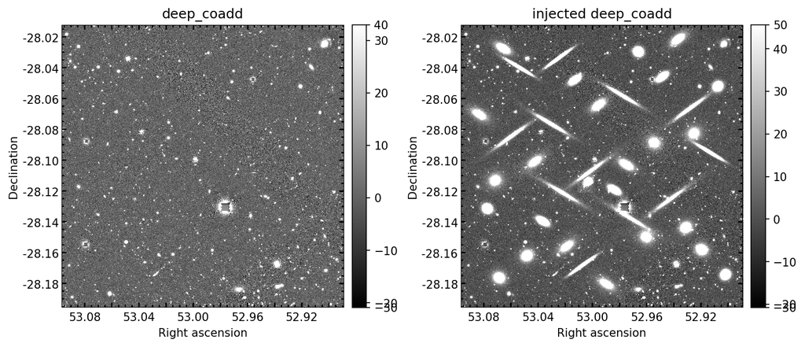

```python
fig, ax = plt.subplots(1, 2, figsize=(10, 6), dpi=150)

plt.sca(ax[0])
display0 = afwDisplay.Display(frame=fig)
display0.scale('linear', 'zscale')
display0.mtv(deep_coadd.image)
plt.title('deep_coadd')

plt.sca(ax[1])
display1 = afwDisplay.Display(frame=fig)
display1.scale('linear', 'zscale')
display1.mtv(injected_image)
plt.title('injected deep_coadd')

plt.tight_layout()
plt.show()
```

> **Figure 2:** The `deep_coadd` before (left) and after (right) synthetic source injection. The `zscale` algorithm sets the display range based on the noise in the image.

Zoom in on the injected postage stamp image.

Use the `bbox_from_sky_circle` method of the `CellCoadd` to compute the bounding box of a circle on the sky, centered on the stamp's (RA, Dec), with a radius of 50 arcseconds (250 pixels). Setting `clip=True` clips the bounding box to the patch, in case the circle extends past the patch edge.

```python
stamp_coord = SkyCoord(ra=my_injection_catalog_stamp['ra'][0],
                       dec=my_injection_catalog_stamp['dec'][0], unit='deg')
stamp_bbox = deep_coadd.bbox_from_sky_circle(stamp_coord, Angle(50, u.arcsec), clip=True)
print(stamp_bbox)
```

```
[y=4070:4571, x=16091:16592]
```

Display the same region of the coadd before and after injection. Indexing an `lsst.images` image with a bounding box (e.g., `deep_coadd.image[stamp_bbox]`) interprets the box in the image's own pixel coordinates, here those of the tract, and returns a new `Image` covering that region.

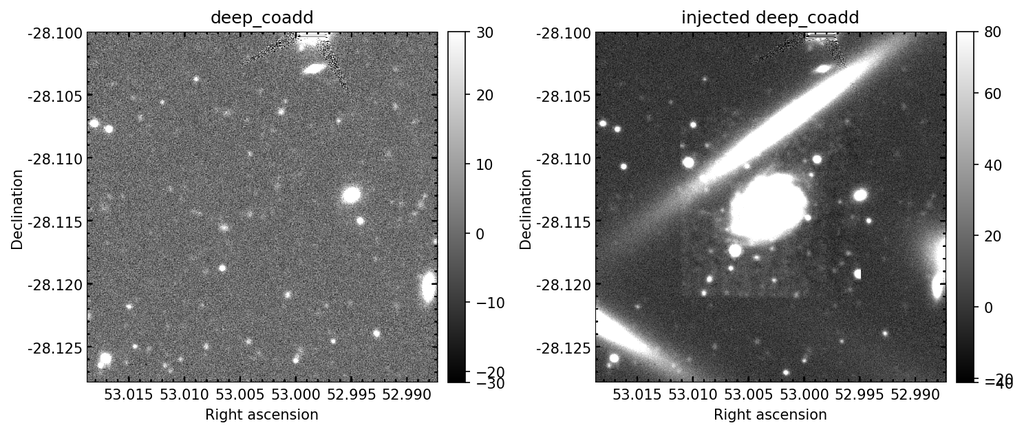

```python
fig, ax = plt.subplots(1, 2, figsize=(10, 6), dpi=150)

plt.sca(ax[0])
display0 = afwDisplay.Display(frame=fig)
display0.scale('linear', 'zscale')
display0.mtv(deep_coadd.image[stamp_bbox])
plt.title('deep_coadd')

plt.sca(ax[1])
display1 = afwDisplay.Display(frame=fig)
display1.scale('linear', 'zscale')
display1.mtv(injected_image[stamp_bbox])
plt.title('injected deep_coadd')

plt.tight_layout()
plt.show()
```

> **Figure 3:** Zoom-in of the injected stamp. The stamp appears inside a faint rectangle. A postage stamp is injected in its entirety, including its own sky noise and any residual background, so the edges of the stamp are visible wherever its noise is larger than that of the image it is injected into. Ideally, postage stamps for injection should be noiseless models, or carefully background-subtracted images.